# Analiza skupień i porządkowanie liniowe

Wiktoria Szczypka

29 listopada 2018

## Wstęp

Mój projekt będzie się składał z trzech części. Najpierw dla wybranego zbioru danych, w celu jego klasyfikacji, przeprowadzę grupowanie przedziałowe i hierarchiczne. Będzie miało to na celu stworzenie grup jak najbardziej od siebie odmiennych, lecz takich, aby elementy były jak najbardziej podobne. Następnie stworzę uniwersalne funkcje, które wykonają rankingi obiektów za pomocą metody Hellwiga i standaryzowanych sum. W trzeciej części za pomocą wcześniejszych funkcji wykonam rankingi moich danych, a następnie wprowadzę do niego rozsądne według mnie wagi.

Moje dane dotyczą telefonów, pochodzą ze strony: http://www.benchmark.pl/ranking/smartfony. Do swojego badania wybrałam 25 obiektów i 7 zmiennych opisujących je.

Teraz przedstawię pierwsze 6 obiektów:

|  | CenaMin | 3DMark Unlimited | Bateria-filmy (min) | Jakość zdjęć | GFXBench T-Rex (KL/S) | JetStream | Waga (g) |
| --- | --- | --- | --- | --- | --- | --- | --- |
| Apple iPhone Xs | 4978 | 76393 | 818 | 5.5 | 60 | 270.0 | 177 |
| Xiaomi Pocophone F1 | 1499 | 62712 | 927 | 4.8 | 60 | 89.2 | 182 |
| Sony Xperia XZ2 Compact | 2049 | 61401 | 658 | 4.6 | 60 | 88.6 | 168 |
| HTC U12+ | 2799 | 60752 | 904 | 5.5 | 60 | 87.0 | 188 |
| Huawei Mate 20 Pro | 4298 | 55232 | 1012 | 5.6 | 60 | 93.4 | 189 |
| Xiaomi Mi Mix 2 | 1679 | 41489 | 771 | 5.3 | 60 | 66.9 | 185 |

Wyjaśnię teraz zmienne:

- CenaMin - minimalna cena w zł, za jaką można kupić dany telefon,
- 3DMark Unlimited - wynik testu wydajności karty graficznej,
- Bateria-filmy(min) - przez ile minut, przy naładowanej baterii, można oglądać filmy,
- Jakość zdjęć - ocena jakości wykonywanych zdjęć,
- GFXBench T-Rex(KL/S) - liczona w klatkach na sekundę wydajność grafiki 3D
- JetStream - wynik testu obsługi JavaScript - większość aplikacji zawiera elementy tego języka programowania
- Waga(g) - waga telefonu podana w gramach

Poniżej przedstawione podstawowe statystyki opisowe oraz wykresy pudełkowe:

```
##     CenaMin     3DMark Unlimited Bateria-filmy (min)  Jakość zdjęć
##  Min.   : 899   Min.   : 9580    Min.   : 594.0      Min.   :4.00
##  1st Qu.:1499   1st Qu.:29004    1st Qu.: 720.0      1st Qu.:4.80
##  Median :1998   Median :33357    Median : 887.0      Median :5.40
##  Mean   :2185   Mean   :37377    Mean   : 848.4      Mean   :5.14
##  3rd Qu.:2799   3rd Qu.:40954    3rd Qu.: 948.0      3rd Qu.:5.50
##  Max.   :4978   Max.   :76393    Max.   :1134.0      Max.   :5.70
##  GFXBench T-Rex (KL/S)   JetStream         Waga (g)
##  Min.   :26.00         Min.   : 23.20   Min.   :113.0
##  1st Qu.:53.00         1st Qu.: 53.30   1st Qu.:155.0
##  Median :60.00         Median : 62.20   Median :176.0
##  Mean   :54.32         Mean   : 75.22   Mean   :169.2
##  3rd Qu.:60.00         3rd Qu.: 87.00   3rd Qu.:185.0
##  Max.   :60.00         Max.   :270.00   Max.   :221.0
```

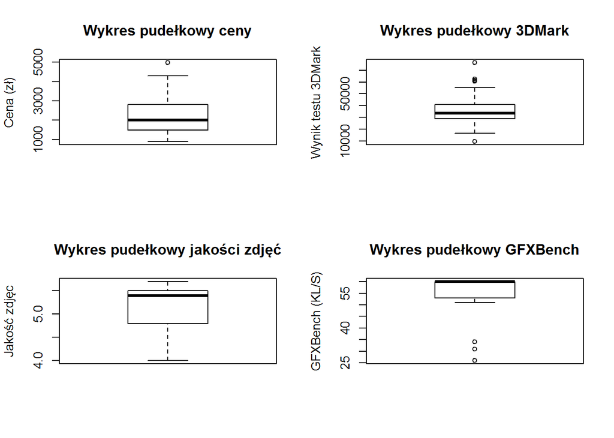

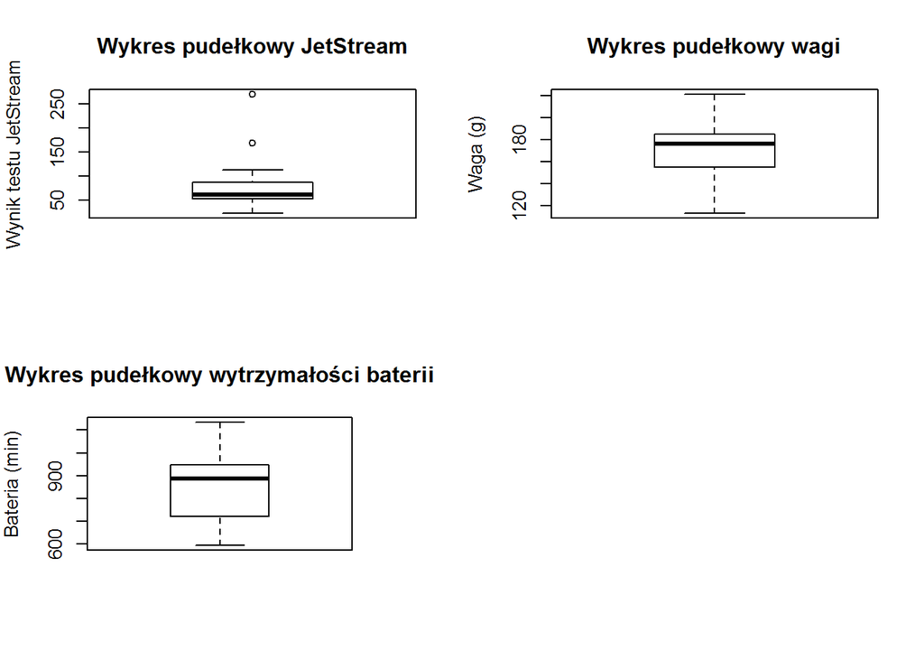

Cena waha się od 899 do 4978zł, mediana to około 2000. Należy się zastanowić czy telefon z ceną 4978 nie jest outlierem. Statystyki testu 3D Mark również sugerują, że telefon o największym wyniku jest obserwacją odstającą. Wytrzymałość baterii waha się od 594 do 1134 minut, jednak mediana to 887 minut. Jakość zdjęć jest zmienną rozłożoną dość równomiernie. Przy wyniku testu GFXBench można zauważyć, że większość telefonów osiąga maksymalny wynik. Analizując zmienną JestStream również widać wartość odstającą od innych - 270. Waga waha się od 113 do 221 gram.

Dalszą analizą obserwacji odstających zajmę się w dalszej części projektu. Moimi głównymi celami będzie pogrupowanie telefonów w taki sposób, aby każda grupa miała sensowną interpretację oraz stworzenie rankingu telefonów w zależności od tego, które parametry są istotniejsze.

## Klasyfikacja

W celu odpowiedniego doboru zmiennych, za pomocą których będę klasyfikować obiekty, policzę ich współczynnik zmienności oraz korelacje jaka zachodzi między nimi. Uznam, że zmienne będą odpowiednie, jeżeli ich współczynnik zmienności będzie większy od 0.1, a wartość bezwzględna korelacji mniejsza od 0.9.

Poniżej korelacja między zmiennymi:

|  | CenaMin | 3DMark Unlimited | Bateria-filmy (min) | Jakość zdjęć | GFXBench T-Rex (KL/S) | JetStream | Waga (g) |
| --- | --- | --- | --- | --- | --- | --- | --- |
| CenaMin | 1.00 | 0.58 | 0.04 | 0.57 | 0.41 | 0.54 | 0.49 |
| 3DMark Unlimited | 0.58 | 1.00 | -0.05 | 0.26 | 0.65 | 0.69 | 0.28 |
| Bateria-filmy (min) | 0.04 | -0.05 | 1.00 | 0.11 | -0.07 | -0.14 | 0.14 |
| Jakość zdjęć | 0.57 | 0.26 | 0.11 | 1.00 | 0.48 | 0.29 | 0.19 |
| GFXBench T-Rex (KL/S) | 0.41 | 0.65 | -0.07 | 0.48 | 1.00 | 0.40 | 0.07 |
| JetStream | 0.54 | 0.69 | -0.14 | 0.29 | 0.40 | 1.00 | -0.08 |
| Waga (g) | 0.49 | 0.28 | 0.14 | 0.19 | 0.07 | -0.08 | 1.00 |

Najwyższa korelacja jest pomiędzy zmienną 3DMark Unlimited, a JetStream, jednak i tak jest ona mniejsza od 0.9, więc korelacja między zmiennymi jest odpowiednia.

Poniżej współczynnik zmienności dla zmiennych:

```
##               CenaMin      3DMark Unlimited   Bateria-filmy (min)
##                 0.491                 0.418                 0.185
##          Jakość zdjęć GFXBench T-Rex (KL/S)             JetStream
##                 0.104                 0.178                 0.668
##              Waga (g)
##                 0.141
```

Widać, że dla zmiennej Jakość zdjęć współczynnik granicy jest minimalnie większy od akceptowalnej wartości. Decyduję się jej nie usuwać, uważam, iż będzie ona ciekawą zmienną do dalszej analizy.

Ze względu na to, że jednostki zmiennych są nieporównywalne, standaryzuje je. Dzięki temu będzie można je porównywać oraz wykryć obserwacje odstające.

Poniżej przedstawiam statystyki i wykresy pudełkowe danych po standaryzacji, aby porównać zmienne między sobą:

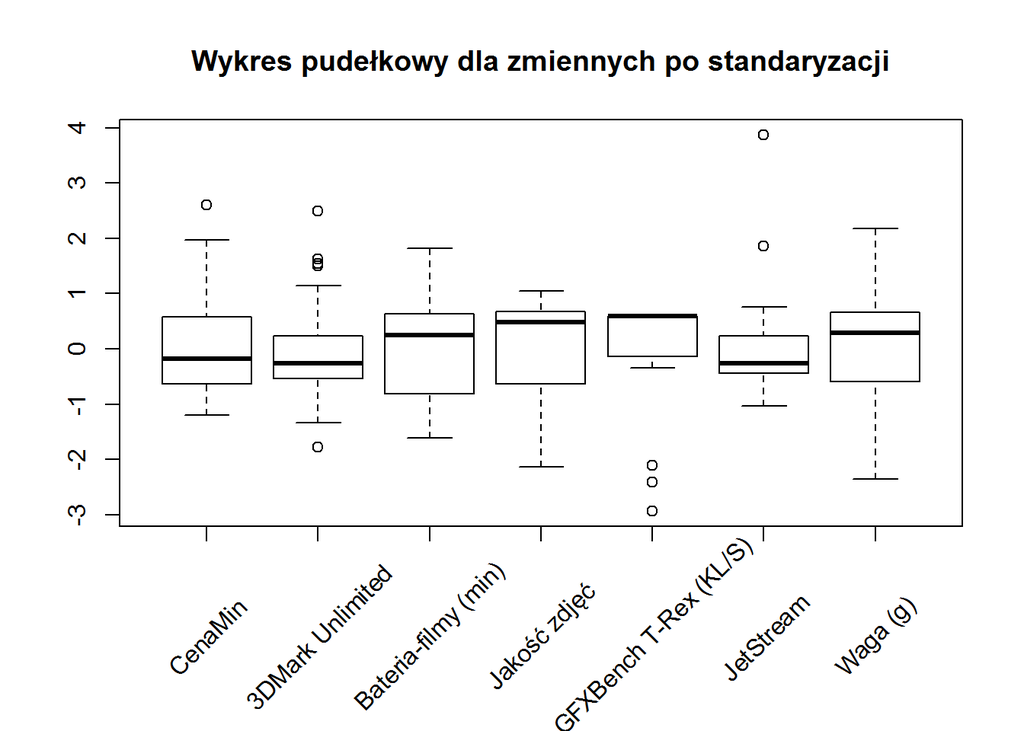

```
##     CenaMin        3DMark Unlimited  Bateria-filmy (min)  Jakość zdjęć
##  Min.   :-1.1985   Min.   :-1.7802   Min.   :-1.6166     Min.   :-2.1354
##  1st Qu.:-0.6395   1st Qu.:-0.5363   1st Qu.:-0.8159     1st Qu.:-0.6369
##  Median :-0.1746   Median :-0.2575   Median : 0.2453     Median : 0.4870
##  Mean   : 0.0000   Mean   : 0.0000   Mean   : 0.0000     Mean   : 0.0000
##  3rd Qu.: 0.5717   3rd Qu.: 0.2291   3rd Qu.: 0.6329     3rd Qu.: 0.6743
##  Max.   : 2.6018   Max.   : 2.4987   Max.   : 1.8148     Max.   : 1.0490
##  GFXBench T-Rex (KL/S)   JetStream          Waga (g)
##  Min.   :-2.9344       Min.   :-1.0348   Min.   :-2.3588
##  1st Qu.:-0.1368       1st Qu.:-0.4361   1st Qu.:-0.5960
##  Median : 0.5885       Median :-0.2591   Median : 0.2854
##  Mean   : 0.0000       Mean   : 0.0000   Mean   : 0.0000
##  3rd Qu.: 0.5885       3rd Qu.: 0.2342   3rd Qu.: 0.6631
##  Max.   : 0.5885       Max.   : 3.8744   Max.   : 2.1741
```

Poniżej ponownie statystyki oraz wykresy pudełkowe zmiennych po usunięciu obserwacji:

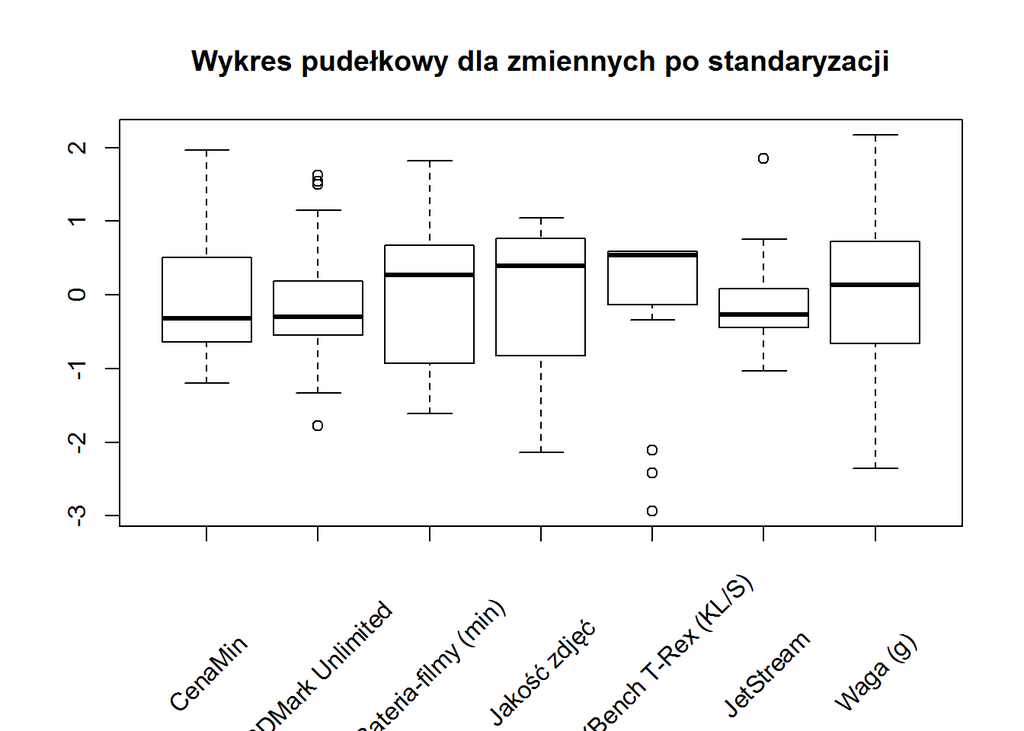

```
##     CenaMin        3DMark Unlimited  Bateria-filmy (min)  Jakość zdjęć
##  Min.   :-1.1985   Min.   :-1.7802   Min.   :-1.616588   Min.   :-2.1354
##  1st Qu.:-0.6395   1st Qu.:-0.5436   1st Qu.:-0.871521   1st Qu.:-0.7305
##  Median :-0.3232   Median :-0.3022   Median : 0.267525   Median : 0.3934
##  Mean   :-0.1084   Mean   :-0.1041   Mean   : 0.008049   Mean   :-0.0281
##  3rd Qu.: 0.4669   3rd Qu.: 0.1723   3rd Qu.: 0.651973   3rd Qu.: 0.7212
##  Max.   : 1.9682   Max.   : 1.6225   Max.   : 1.814849   Max.   : 1.0490
##  GFXBench T-Rex (KL/S)   JetStream             Waga (g)
##  Min.   :-2.93439      Min.   :-1.0348382   Min.   :-2.35879
##  1st Qu.:-0.13677      1st Qu.:-0.4425672   1st Qu.:-0.62747
##  Median : 0.53673      Median :-0.2690134   Median : 0.13851
##  Mean   :-0.02452      Mean   :-0.1614332   Mean   :-0.01364
##  3rd Qu.: 0.58854      3rd Qu.: 0.0000199   3rd Qu.: 0.69463
##  Max.   : 0.58854      Max.   : 1.8554046   Max.   : 2.17412
```

Można zauważyć, że teraz nie ma już tak wiele wartości odstających jak wcześniej. Obserwacja ta ewidentnie była outlierem - telefon miał bardzo dobre parametry, lecz był też o wiele droższy od innych.

Teraz przeprowadzę grupowanie przedziałowe i hierarchiczne zmiennych, a potem przedstawię podobieństwa oraz różnice między oboma sposobami. Na końcu wybiorę, moim zdaniem, najlepsze grupowanie obserwacji.

### Grupowanie przedziałowe

Do mojego badania użyję dwie funkcję - `kmeans` oraz `pam`. Pierwsza z nich jest odzwierciedleniem metody k-średnich, a druga odmianą metody k-medoid.

Podstawowym problemem w grupowaniu przedziałowym jest to, że liczbę skupień (grup) trzeba znać z góry.

W celu zbadania jaka ilość grup będzie najlepsza stworzę przy pomocy funkcji `kmeans` wykres tzw. łokciowy. Wykres przypomina swoim wyglądem łokieć, a punkt załamania - czyli, że wartości krzywej przestaną szybko maleć będzie najlepszą liczbą klas (według tej metody).

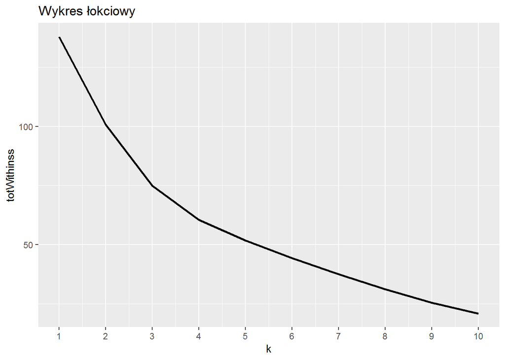

Widać, że w tym przypadku ciężko stwierdzić, gdzie jest załamanie. Podejrzewałabym, że jest to k = 3 lub k = 4.

Wykonam jeszcze jeden wykres, który ma służyć do pomocy w wyborze jaka liczba klas będzie najlepsza. Tym razem za pomocą funkcji `pam`. Według tej metody najlepsza liczba klas to ta, gdzie krzywa ma największą wartość.

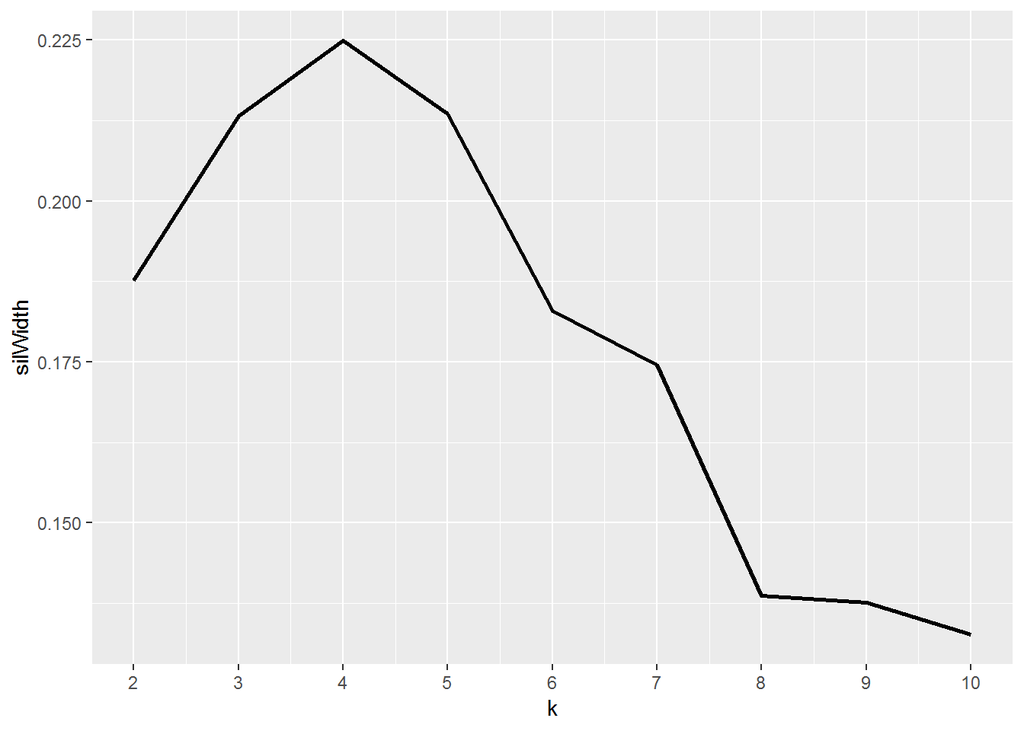

Przy pomocy tej metody ewidentnie widać, że najlepsza ilość klas to 4.

Ze względu na to, że wyniki nie są do końca jasne policzę indeksy Calińskiego i Harabasza (G1), Bakera i Huberta (G2), Huberta i Levine’a (G3) oraz Silhouette. Dla G1, G2 i Silhouette najlepsza będzie maksymalna wartość, a dla G3 minimalna.

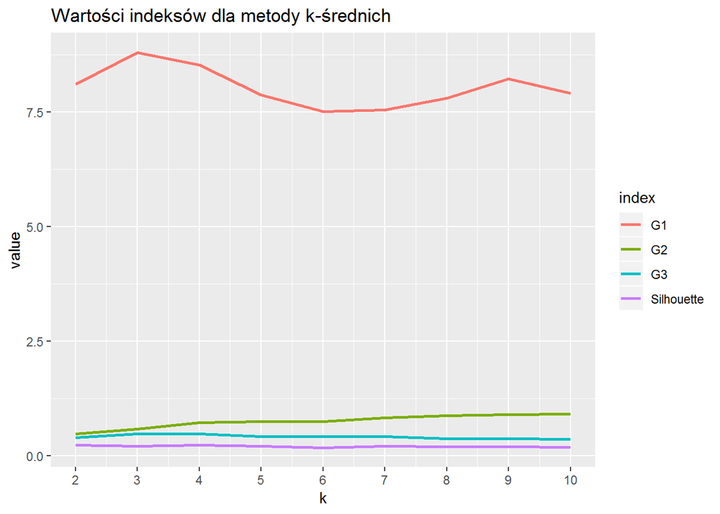

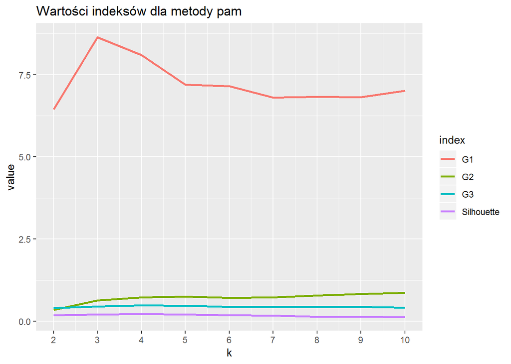

W tym przypadku podobnie jak wcześniej tylko z indeksu G1 można zauważyć, że prawdopodobnie najlepsza liczba klas to 3.

Ze względu na otrzymane wyniki wykonuje analizę dla liczby skupień równej 3. Poniżej przedstawię przydział telefonów do grup za pomocą obu metod.

```
##                         k3 pam3
## Xiaomi Pocophone F1      3    1
## Sony Xperia XZ2 Compact  3    2
## HTC U12+                 1    1
## Huawei Mate 20 Pro       1    1
## Xiaomi Mi Mix 2          3    1
## Samsung Galaxy Note 9    1    1
## Honor Play               3    2
## HTC U11                  3    2
## Sony Xperia XZ1          3    2
## Samsung Galaxy S9+       1    1
## Apple iPhone 7           3    2
## Google Pixel 2 XL        1    1
## LG V30                   3    1
## Huawei Mate 10 Pro       1    1
## Samsung Galaxy Note 8    1    1
## Huawei P20 Pro           1    1
## Apple iPhone SE          3    2
## Samsung Galaxy S7        3    2
## Huawei P10               3    2
## Lenovo Moto Z            3    2
## Honor 9                  3    2
## Nokia 7.1                2    3
## Sony Xperia XA2 Ultra    2    3
## Xiaomi Redmi 3S          2    3
```

Widać, że 3 ostatnie pozycje są takie same i w obu przypadkach stanowią jedną grupę. W pozostałych dwóch grupach można zauważyć małe różnice.

### Grupowanie hierarchiczne

Do grupowania hierarchicznego użyję funkcji `hclust`. Argumentem tej funkcji jest macierz odległości między danymi. Do obliczenia odległości wykorzystuje jedną z popularniejszych metod - euklidesową. Funkcja ta ma też możliwość wyboru metody za pomocą której dokona grupowania hierarchicznego. Wykonam grupowanie dla czterech z nich i postaram się wybrać najlepszą opcję.

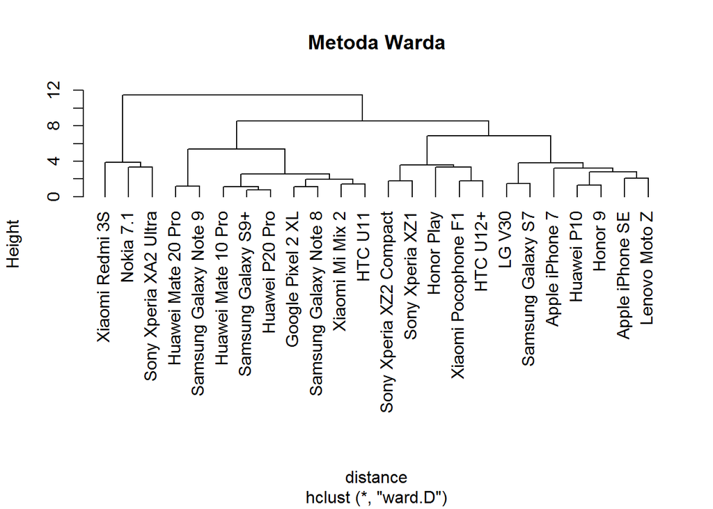

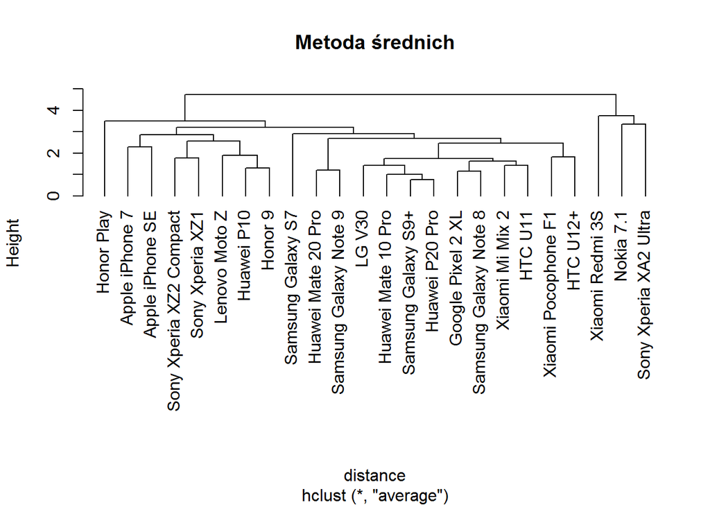

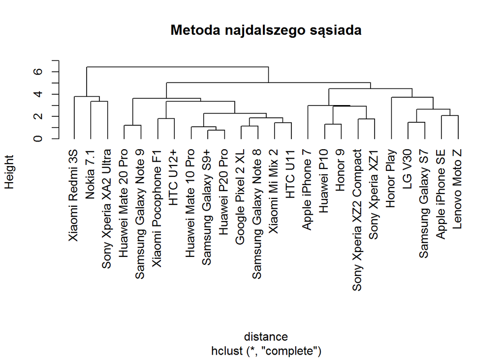

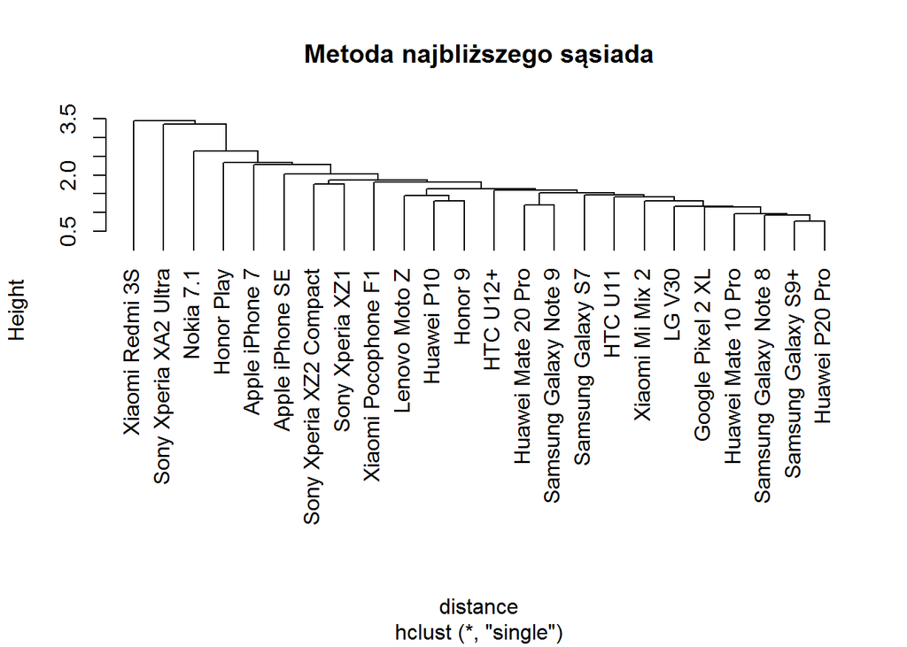

Z powyższych dendrogramów można zauważyć, że wykonanie go za pomocą metody Warda jest najbardziej czytelne. W praktyce to właśnie ona jest najczęściej wykorzystywana. Pozostałe mają różne wady. Do dalszej analizy wykorzystam właśnie tę metodę. Poniżej ponownie przedstawiam dendrogram wykonany metodą Warda.

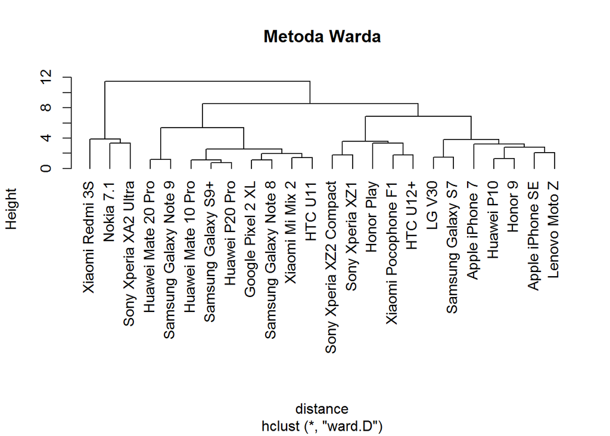

Aby zdecydować jaka liczba klas będzie najlepsza policzę 4 indeksy - Calińskiego i Harabasza (G1), Bakera i Huberta (G2), Huberta i Levine’a (G3) oraz Silhouette. Dla G1, G2 i Silhouette najlepsza będzie maksymalna wartość, a dla G3 minimalna.

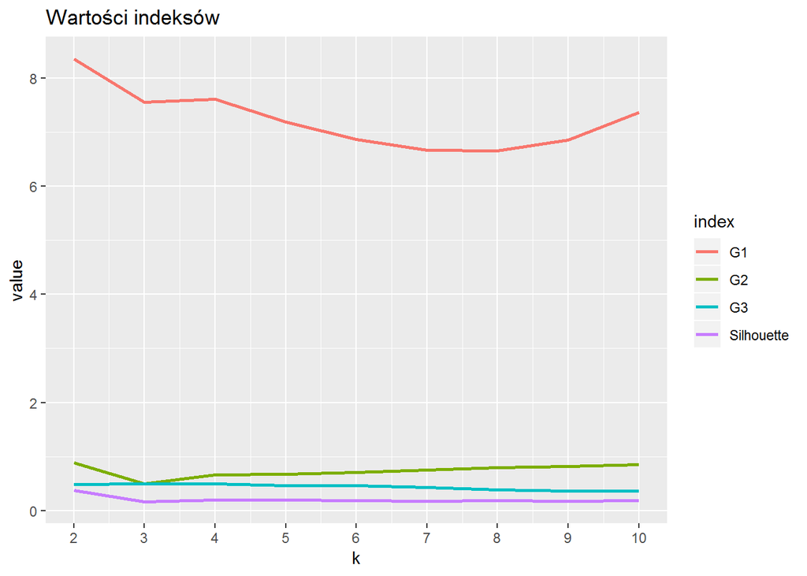

Wynik nie jest dość jasny. G1, G2 oraz Silhouette sugerują, że liczba klas powinna wynosić 2, lecz w przypadku G2 wynik zaczyna wraz ze wzrostem klas rosnąć, G3 jest prawie prostą linią. Ze względu na wyniki indeksów oraz własną ocenę dendrogramu przedstawiam dwie propozycje podziału:

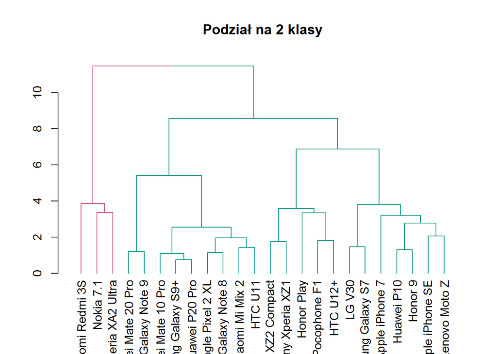

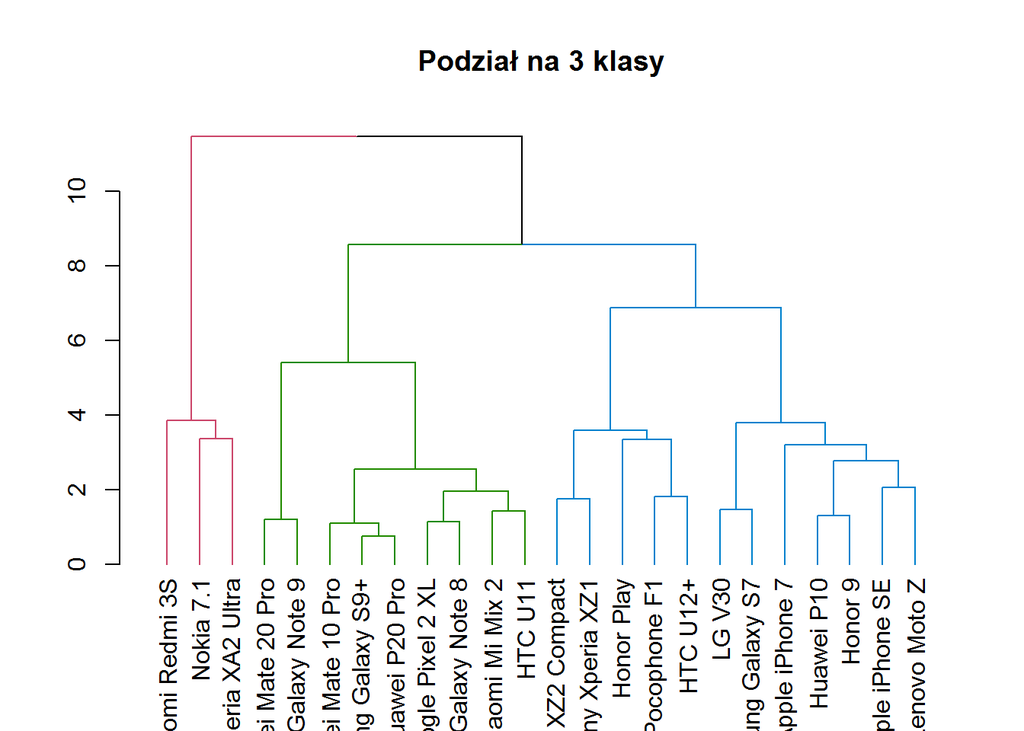

Jak widać podział na 2 części jest bardzo nierównomierny.

Poniżej przedstawię przydział telefonów do grup za pomocą obu podziałów.

```
##                         cl3 cl2
## Xiaomi Pocophone F1       1   1
## Sony Xperia XZ2 Compact   1   1
## HTC U12+                  1   1
## Huawei Mate 20 Pro        2   1
## Xiaomi Mi Mix 2           2   1
## Samsung Galaxy Note 9     2   1
## Honor Play                1   1
## HTC U11                   2   1
## Sony Xperia XZ1           1   1
## Samsung Galaxy S9+        2   1
## Apple iPhone 7            1   1
## Google Pixel 2 XL         2   1
## LG V30                    1   1
## Huawei Mate 10 Pro        2   1
## Samsung Galaxy Note 8     2   1
## Huawei P20 Pro            2   1
## Apple iPhone SE           1   1
## Samsung Galaxy S7         1   1
## Huawei P10                1   1
## Lenovo Moto Z             1   1
## Honor 9                   1   1
## Nokia 7.1                 3   2
## Sony Xperia XA2 Ultra     3   2
## Xiaomi Redmi 3S           3   2
```

Ponownie widać, że jedna grupa w obu przypadkach jest taka sama. Według mnie podział na dwie grupy jest zbyt ogólny.

### Podsumowanie

Poniżej tabela z przydziałem do klas za pomocą odpowiednio - k-means (k = 3), pam (k = 3) oraz grupowanie hierarchiczne (k = 3 i k = 2)

```
##                         k3 pam3 cl3 cl2
## Xiaomi Pocophone F1      3    1   1   1
## Sony Xperia XZ2 Compact  3    2   1   1
## HTC U12+                 1    1   1   1
## Huawei Mate 20 Pro       1    1   2   1
## Xiaomi Mi Mix 2          3    1   2   1
## Samsung Galaxy Note 9    1    1   2   1
## Honor Play               3    2   1   1
## HTC U11                  3    2   2   1
## Sony Xperia XZ1          3    2   1   1
## Samsung Galaxy S9+       1    1   2   1
## Apple iPhone 7           3    2   1   1
## Google Pixel 2 XL        1    1   2   1
## LG V30                   3    1   1   1
## Huawei Mate 10 Pro       1    1   2   1
## Samsung Galaxy Note 8    1    1   2   1
## Huawei P20 Pro           1    1   2   1
## Apple iPhone SE          3    2   1   1
## Samsung Galaxy S7        3    2   1   1
## Huawei P10               3    2   1   1
## Lenovo Moto Z            3    2   1   1
## Honor 9                  3    2   1   1
## Nokia 7.1                2    3   3   2
## Sony Xperia XA2 Ultra    2    3   3   2
## Xiaomi Redmi 3S          2    3   3   2
```

Można zauważyć, że jedna grupa bez względu na metodę klasteryzacji jest taka sama - są to telefony najsłabsze. W przypadku podziale na 3 grupy różnice są niewielkie.

Jako finalnie najlepszy wynik wybieram liczbę skupień 3 za pomocą metody grupowania przedziałowego k-średnich.

Poniżej przedstawiam statystyki dla tej grupy:

średnia:

| k3 | CenaMin | 3DMark Unlimited | Bateria-filmy (min) | Jakość zdjęć | GFXBench T-Rex (KL/S) | JetStream | Waga (g) |
| --- | --- | --- | --- | --- | --- | --- | --- |
| 1 | 3094.88 | 40361.88 | 888.75 | 5.59 | 59.38 | 68.10 | 187.00 |
| 2 | 1315.67 | 15294.67 | 877.67 | 4.33 | 30.33 | 31.43 | 175.00 |
| 3 | 1611.62 | 37635.62 | 819.15 | 5.02 | 56.31 | 74.73 | 156.31 |

Odchylenie standardowe:

| k3 | CenaMin | 3DMark Unlimited | Bateria-filmy (min) | Jakość zdjęć | GFXBench T-Rex (KL/S) | JetStream | Waga (g) |
| --- | --- | --- | --- | --- | --- | --- | --- |
| 1 | 802.69 | 11481.40 | 117.24 | 0.08 | 1.77 | 14.67 | 8.62 |
| 2 | 361.71 | 5186.39 | 267.64 | 0.29 | 4.04 | 10.83 | 40.63 |
| 3 | 399.23 | 12307.72 | 165.14 | 0.48 | 3.73 | 35.14 | 20.30 |

Telefony dzielą się na 3 grupy:

- Najdroższe, najlepsze graficznie, najlepsze do robienia zdjęć, najdłużej trzymające baterie, lecz najcięższe oraz nie tak dobre w obsłudze JavaScript. Sądzę, że są to telefony dla ludzi, którym zależy na dobrej grafice, graniu w gry oraz na bardzo dobrej jakości robienia zdjęć.
- Najtańsze, z o wiele gorszymi wynikami testów, przeciętnej wagi, za to również dobrze trzymające baterie. Myślę, że są to telefony dla osób, którym nie zależy na wysokich parametrach telefonu, lecz na niskiej cenie i tym, by bateria wytrzymywała dość długo. Można się domyślać, że są to te trzy telefony, które odstawały na wykresie pudełkowym zmiennej GFXBench.
- Średniej ceny o dobrych graficznie i dobrej jakości zdjęć, lecz gorszej niż w przypadku pierwszej grupy. Za to są lepsze w obsłudze JavaScripu oraz są najlżejsze. Minusem jest słabsza bateria. Telefony te są więc skierowane do ‘przeciętnego’ użytkownika, któremu nie zależy na bardzo dobrej grafice, ważniejsza jest obsługa aplikacji i lekkość telefonu.

## Funkcje

Przedstawię teraz funkcje, które za pomocą metody Hellwiga oraz standaryzowanych sum (metoda porządkowania liniowego) tworzą ranking obiektów.

Jako parametry wejściowe przyjmują one `df` - ramkę danych, gdzie pierwsza kolumna to nazwy obiektów, a pozostałe to numeryczne zmienne oraz `wzorzec` - wektor, który odpowiada kolejnym zmiennym (bez nazwy) i przedstawia czy zmienna jest stymulantą (“+”), destymulanta (“-”) lub nominantą (konkretna wartość).

Pierwsza funkcja za pomocą algorytmu metody Hellwiga tworzy ranking - od najlepszego do najgorszego obiektu.

```r
sortHellwig <- function(df, wzorzec) {
  row <- nrow(df)
  col <- ncol(df)
  len <- length(wzorzec)

  for(i in 1:len) {
    if(wzorzec[i]!="+" && wzorzec[i]!="-") {
      wzorzec[i] = (as.numeric(wzorzec[i])-mean(df[,i+1]))/sd(df[,i+1])
    }
  }

  df[,2:col] <- scale(df[,2:col])

  for(i in 1:len) {
    if(wzorzec[i] == "+") {
      wzorzec[i] = max(df[,i+1])
    } else if(wzorzec[i]=="-") {
      wzorzec[i] = min(df[,i+1])
    } else{
    }
  }


  wzorzec <- as.numeric(c(NA, wzorzec))
  df <- rbind(df,wzorzec)

  for(i in 1:row) {
    df[i,col+1] <- dist(df[i,2:col], df[row+1,2:col])
  }


  df[,col+1] <- as.vector(df[,col+1] )


  d <- mean(df[1:row,col+1]) + 2*sd(df[1:row,col+1])

  for(i in 1:row) {
    df[i,col+2] <- 1-df[i,col+1]/d
  }

  df[,col+2] <- as.vector(df[,col+2] )

  names(df)[col+1] <- "odleglosc"
  names(df)[col+2] <- "wynik"

  arrange(df[1:row,], desc(wynik))

}
```

Druga funkcja tworzy ranking za pomocą algorytmu metody standaryzowanych sum, również od najlepszego obiektu do najgorszego.

```r
sortSum <- function(df, wzorzec) {
  row <- nrow(df)
  col <- ncol(df)
  len <- length(wzorzec)

  for(i in 1:len) {
    if(wzorzec[i]!="+" && wzorzec[i]!="-") {
      for(j in 1:row) {
        df[j,i+1] <- - abs(df[j, i+1] - as.numeric(wzorzec[i]))
      }
    }
  }

  for(i in 1:len) {
    if(wzorzec[i] == "-") {
      df[,i+1] = - df[,i+1]
    }
  }

  df[,2:col] <- scale(df[,2:col])

  for(i in 1:row) {
    df[i,col+1] <- sum(df[i,2:col])
  }

  df[,col+1] <- as.vector(df[,col+1] )

  for(i in 1:row) {
    df[i,col+2] <- (df[i,col+1] - min(df[,col+1])) / max(df[,col+1] - min(df[,col+1]))
  }

  df[,col+2] <- as.vector(df[,col+2] )

  names(df)[col+1] <- "suma"
  names(df)[col+2] <- "wynik"

  arrange(df[1:row,], desc(wynik))

}
```

## Porządkowanie liniowe

W tej części projektów stworzę rankingi telefonów. Aby je stworzyć muszę wybrać na jakiej podstawie mają być tworzone tzn. jaki charakter będą miały poszczególne zmienne.

- CenaMin - przy kupowaniu telefonów dla klienta ważna jest cena - najlepiej aby była jak najmniejsza, zmienna ta będzie destymulantą (preferowane są możliwie niskie wartości)
- Parametry 3DMark, Bateria, Jakość zdjęć, GFXBench, JetStream świadczą o tym jak dobry jest telefon. Pożądane są więc jak najwyższe wartości - zmienne będą stymulantami
- Waga - wydaje mi się, że najlepiej jest jak telefon nie jest ani za ciężki, ani za lekki. Zmienna ta więc będzie nominantą, ustalam optymalna wartość jako 170 gram.

Najpierw wykonam 2 rankingi bez użycia wag. Pierwszy z nich wykonam metodą Hellwiga za pomocą przedstawionej wcześniej funkcji.

```
##                      Nazwa        wynik
## 1          Apple iPhone Xs  0.440975444
## 2      Xiaomi Pocophone F1  0.438898169
## 3                 HTC U12+  0.418501601
## 4           Apple iPhone 7  0.395883867
## 5       Huawei Mate 20 Pro  0.347511368
## 6        Samsung Galaxy S7  0.332281875
## 7          Xiaomi Mi Mix 2  0.314442796
## 8          Apple iPhone SE  0.310873246
## 9  Sony Xperia XZ2 Compact  0.309987233
## 10                 HTC U11  0.300492988
## 11      Huawei Mate 10 Pro  0.298453651
## 12      Samsung Galaxy S9+  0.297708165
## 13                  LG V30  0.281177210
## 14          Huawei P20 Pro  0.255928940
## 15   Samsung Galaxy Note 8  0.252937438
## 16              Honor Play  0.244489183
## 17   Samsung Galaxy Note 9  0.244486326
## 18              Huawei P10  0.225349384
## 19       Google Pixel 2 XL  0.212157438
## 20         Sony Xperia XZ1  0.189973812
## 21           Lenovo Moto Z  0.178066326
## 22                 Honor 9  0.112631917
## 23   Sony Xperia XA2 Ultra  0.005284677
## 24         Xiaomi Redmi 3S -0.010161467
## 25               Nokia 7.1 -0.024791401
```

Drugi ranking wykonuję za pomocą metody standaryzowanych sum:

```
##                      Nazwa      wynik
## 1          Apple iPhone Xs 1.00000000
## 2      Xiaomi Pocophone F1 0.82986541
## 3                 HTC U12+ 0.78008681
## 4        Samsung Galaxy S7 0.75431040
## 5       Huawei Mate 10 Pro 0.71969765
## 6       Huawei Mate 20 Pro 0.71685339
## 7                  HTC U11 0.70596166
## 8  Sony Xperia XZ2 Compact 0.67781804
## 9          Xiaomi Mi Mix 2 0.65729103
## 10              Honor Play 0.65325452
## 11      Samsung Galaxy S9+ 0.63717449
## 12          Apple iPhone 7 0.61823222
## 13                  LG V30 0.61063626
## 14          Huawei P20 Pro 0.60665962
## 15   Samsung Galaxy Note 9 0.55282846
## 16       Google Pixel 2 XL 0.53929808
## 17   Samsung Galaxy Note 8 0.52762238
## 18         Apple iPhone SE 0.48623528
## 19              Huawei P10 0.46624246
## 20         Sony Xperia XZ1 0.45696128
## 21           Lenovo Moto Z 0.42010795
## 22                 Honor 9 0.31248825
## 23         Xiaomi Redmi 3S 0.21897770
## 24               Nokia 7.1 0.07612128
## 25   Sony Xperia XA2 Ultra 0.00000000
```

Poniżej porównanie wyników obu metod:

```
##                      Nazwa        wynik                 Nazwa.1    wynik.1
## 1          Apple iPhone Xs  0.440975444         Apple iPhone Xs 1.00000000
## 2      Xiaomi Pocophone F1  0.438898169     Xiaomi Pocophone F1 0.82986541
## 3                 HTC U12+  0.418501601                HTC U12+ 0.78008681
## 4           Apple iPhone 7  0.395883867       Samsung Galaxy S7 0.75431040
## 5       Huawei Mate 20 Pro  0.347511368      Huawei Mate 10 Pro 0.71969765
## 6        Samsung Galaxy S7  0.332281875      Huawei Mate 20 Pro 0.71685339
## 7          Xiaomi Mi Mix 2  0.314442796                 HTC U11 0.70596166
## 8          Apple iPhone SE  0.310873246 Sony Xperia XZ2 Compact 0.67781804
## 9  Sony Xperia XZ2 Compact  0.309987233         Xiaomi Mi Mix 2 0.65729103
## 10                 HTC U11  0.300492988              Honor Play 0.65325452
## 11      Huawei Mate 10 Pro  0.298453651      Samsung Galaxy S9+ 0.63717449
## 12      Samsung Galaxy S9+  0.297708165          Apple iPhone 7 0.61823222
## 13                  LG V30  0.281177210                  LG V30 0.61063626
## 14          Huawei P20 Pro  0.255928940          Huawei P20 Pro 0.60665962
## 15   Samsung Galaxy Note 8  0.252937438   Samsung Galaxy Note 9 0.55282846
## 16              Honor Play  0.244489183       Google Pixel 2 XL 0.53929808
## 17   Samsung Galaxy Note 9  0.244486326   Samsung Galaxy Note 8 0.52762238
## 18              Huawei P10  0.225349384         Apple iPhone SE 0.48623528
## 19       Google Pixel 2 XL  0.212157438              Huawei P10 0.46624246
## 20         Sony Xperia XZ1  0.189973812         Sony Xperia XZ1 0.45696128
## 21           Lenovo Moto Z  0.178066326           Lenovo Moto Z 0.42010795
## 22                 Honor 9  0.112631917                 Honor 9 0.31248825
## 23   Sony Xperia XA2 Ultra  0.005284677         Xiaomi Redmi 3S 0.21897770
## 24         Xiaomi Redmi 3S -0.010161467               Nokia 7.1 0.07612128
## 25               Nokia 7.1 -0.024791401   Sony Xperia XA2 Ultra 0.00000000
```

Można zauważyć, że 3 pierwsze pozycje pozostają bez zmian w obu rankingach. 3 najgorsze telefony w obu rankingach są takie same, lecz różnią się miejscami. Miejsca 13 i 14 w obu rankingach są takie same. Pozostałe pozycje są wymieszane w swoich grupach. Fakt, że mimo tego, że chcemy minimalizować cenę, na pierwszym miejscu jest najdroższy wynika z tego, że jego pozostałe parametry są bardzo dobre. Wprowadzę teraz wybrane przez siebie wagi, gdzie cena telefonu będzie najważniejszym kryterium. Poniżej przedstawiam wybrane przeze mnie wagi dla każdej ze zmiennej:

```r
wagi <- c(.4, .05, .1, .15, .05, .15, .1)
```

Zmienna Cena jest według mnie najważniejsza, dlatego ustalam ją jako taką wysoką. Ważna jest tez jakość zdjęć i obsługa JavaScript (niezbędna do korzystania z wielu aplikacji). Najmniej istotne są dla mnie zmienne 3DMark oraz GFXBench - nie zależy mi, żeby telefon miał aż tak rozwiniętą grafikę. Zmiennymi pośrednimi jest bateria i waga - są one ważne, ale nie najważniejsze.

```
##                      Nazwa     wynik
## 1        Samsung Galaxy S7 1.0000000
## 2                  HTC U11 0.8930670
## 3      Xiaomi Pocophone F1 0.8704843
## 4       Huawei Mate 10 Pro 0.7382865
## 5          Xiaomi Mi Mix 2 0.7142633
## 6           Apple iPhone 7 0.6886061
## 7          Apple iPhone SE 0.6880004
## 8               Honor Play 0.6808870
## 9            Lenovo Moto Z 0.6497051
## 10              Huawei P10 0.5747903
## 11                  LG V30 0.5659678
## 12                HTC U12+ 0.5625086
## 13 Sony Xperia XZ2 Compact 0.5556884
## 14         Xiaomi Redmi 3S 0.5499810
## 15         Sony Xperia XZ1 0.4653264
## 16          Huawei P20 Pro 0.4230999
## 17      Samsung Galaxy S9+ 0.4223759
## 18         Apple iPhone Xs 0.3978489
## 19   Samsung Galaxy Note 8 0.3902380
## 20       Google Pixel 2 XL 0.3377121
## 21                 Honor 9 0.2987471
## 22      Huawei Mate 20 Pro 0.1605655
## 23               Nokia 7.1 0.1602281
## 24   Sony Xperia XA2 Ultra 0.1114836
## 25   Samsung Galaxy Note 9 0.0000000
```

Widać, że ranking wygląda teraz zupełnie inaczej. Wyświetlę teraz telefony, cenę oraz ich przydział do klas z pierwszej części projektu:

```
##                         CenaMin k3
## Xiaomi Pocophone F1        1499  3
## Sony Xperia XZ2 Compact    2049  3
## HTC U12+                   2799  1
## Huawei Mate 20 Pro         4298  1
## Xiaomi Mi Mix 2            1679  3
## Samsung Galaxy Note 9      4298  1
## Honor Play                 1348  3
## HTC U11                    1499  3
## Sony Xperia XZ1            1499  3
## Samsung Galaxy S9+         2919  1
## Apple iPhone 7             2099  3
## Google Pixel 2 XL          2998  1
## LG V30                     2299  3
## Huawei Mate 10 Pro         1999  1
## Samsung Galaxy Note 8      2649  1
## Huawei P20 Pro             2799  1
## Apple iPhone SE            1249  3
## Samsung Galaxy S7          1285  3
## Huawei P10                 1549  3
## Lenovo Moto Z               899  3
## Honor 9                    1998  3
## Nokia 7.1                  1499  2
## Sony Xperia XA2 Ultra      1549  2
## Xiaomi Redmi 3S             899  2
```